# QC

Gijsje

2/3/2021

```r
setwd("~/Documents/MiGASti/Databases")
multi_qc_data = "~/Documents/MiGASti/Databases/multiqc_general_stats_533s.txt"
general_stats <- read.table("multiqc_general_stats_533s.txt", header=T, stringsAsFactors = FALSE)
multiqc_picard_coverage = read.table("mqc_picard_rna_coverage_1.txt", header = T, stringsAsFactors = F, check.names = F, sep = "\t", row.names = 1)
picard_rnaseqmetrics = read.table("mqc_picard_rnaseqmetrics_assignment_plot_1.txt", header = T, stringsAsFactors = F, check.names = F, sep = '\t')
```

# Uniquely mapped reads

### Mean aligned uniquely mapped reads

```r
mean_aligned = mean(general_stats$STAR_mqc.generalstats.star.uniquely_mapped, na.rm = T)
mean_aligned
```

[1] 27823519

### Median aligned uniquely mapped reads

```r
median_aligned = median(general_stats$STAR_mqc.generalstats.star.uniquely_mapped, na.rm = T)
median_aligned
```

[1] 27826644

### Maximum aligned uniquely mapped reads

```r
max_aligned = max(general_stats$STAR_mqc.generalstats.star.uniquely_mapped, na.rm = T)
na.omit(general_stats[general_stats$STAR_mqc.generalstats.star.uniquely_mapped == max_aligned, c("Sample", "STAR_mqc.generalstats.star.uniquely_mapped")])
```

|  | Sample | STAR_mqc.generalstats.star.uniquely_mapped |
| --- | --- | --- |
| 526 | 14-046-CC-LPS | 127595848 |

### Minimum aligned uniquely mapped reads

```r
min_aligned = min(general_stats$STAR_mqc.generalstats.star.uniquely_mapped , na.rm = T)
na.omit(general_stats[general_stats$STAR_mqc.generalstats.star.uniquely_mapped == min_aligned, c("Sample", "STAR_mqc.generalstats.star.uniquely_mapped")])
```

|  | Sample | STAR_mqc.generalstats.star.uniquely_mapped |
| --- | --- | --- |
| 91 | 18-064-GFM-IFNy | 64850 |

### Distrubution plot aligned uniquely mapped reads

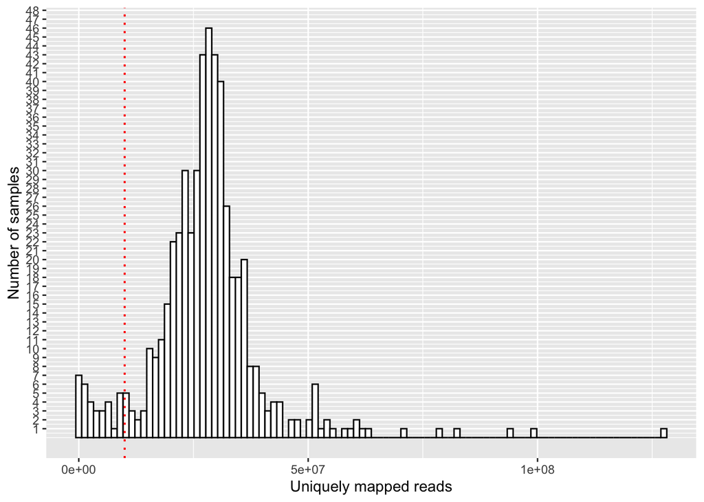

```r
ggplot(general_stats, aes(x=STAR_mqc.generalstats.star.uniquely_mapped)) +
  geom_histogram(bins = 100,
                 colour="black", fill="white", xlab="test") +
  labs(x="Uniquely mapped reads", y="Number of samples") +
  geom_vline(xintercept = 10000000, linetype="dotted", color="red", size=0.7) +
  scale_y_continuous(breaks = (1:100))
```

# Mapped reads * (1- percent duplication)

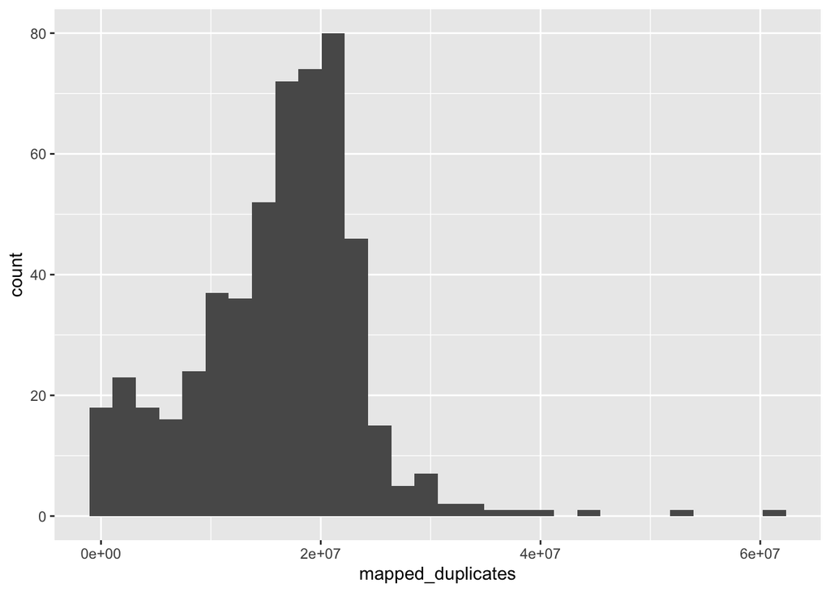

```r
mapped_duplicates = general_stats$STAR_mqc.generalstats.star.uniquely_mapped * (1- general_stats$Picard_mqc.generalstats.picard.PERCENT_DUPLICATION)
ggplot() + geom_histogram(aes(mapped_duplicates))
```

### Median

```r
median(mapped_duplicates)
```

[1] 16976546

### Standard deviation

```r
sd(mapped_duplicates)
```

[1] 7587867

# STAR

### STAR < 10 million reads

```r
star_alignment_10m = general_stats$Sample[which(general_stats$STAR_mqc.generalstats.star.uniquely_mapped < 10000000)]
length(star_alignment_10m)
```

[1] 35

```r
unique(star_alignment_10m)
```

[1] “18-021-GFM-DEX” “18-021-GFM-LPS” “18-021-THA-LPS”  
[4] “18-064-GFM-ATP” “18-064-GFM-IFNy” “18-064-GFM-unstim” [7] “18-105-GTS-LPS” “18-105-GTS-unstim” “18-118-GFM-IL4”  
[10] “MG-15-SN-RNA” “16-082-SVZ-IFNy” “16-082-SVZ-unstim” [13] “16-117-GFM-DEX” “16-117-SVZ-unstim” “17-003-GTS-LPS”  
[16] “17-017-GFM-unstim” “17-029-GFM-LPS” “17-029-GTS-unstim” [19] “17-032-SVZ-IFNy” “17-078-GFM-TNFa” “13-087-CC-LPS”  
[22] “14-053-CC-IFNy” “14-063-CC-LPS” “14-075-GFM-IFNy”  
[25] “14-075-GFM-LPS” “14-075-GFM-TNFa” “14-075-GTS-LPS”  
[28] “15-055-GFM-DEX” “15-089-GTS-unstim” “15-089-THA-LPS”  
[31] “15-089-THA-unstim” “16-003-SVZ-IFNy” “16-003-SVZ-R848”  
[34] “16-003-SVZ-TNFa” “16-003-SVZ-unstim”

### STAR < 5 million reads

```r
star_alignment_5m = general_stats$Sample[which(general_stats$STAR_mqc.generalstats.star.uniquely_mapped < 5000000)]
length(star_alignment_5m)
```

[1] 21

```r
unique(star_alignment_5m)
```

[1] “18-021-GFM-DEX” “18-021-GFM-LPS” “18-064-GFM-ATP”  
[4] “18-064-GFM-IFNy” “18-064-GFM-unstim” “18-105-GTS-LPS”  
[7] “18-105-GTS-unstim” “18-118-GFM-IL4” “MG-15-SN-RNA”  
[10] “16-117-SVZ-unstim” “17-003-GTS-LPS” “17-017-GFM-unstim” [13] “17-032-SVZ-IFNy” “13-087-CC-LPS” “14-075-GFM-IFNy”  
[16] “14-075-GFM-LPS” “14-075-GFM-TNFa” “15-055-GFM-DEX”  
[19] “15-089-GTS-unstim” “15-089-THA-LPS” “15-089-THA-unstim”

### STAR < 1 million reads

```r
star_alignment_1m = general_stats$Sample[which(general_stats$STAR_mqc.generalstats.star.uniquely_mapped < 1000000)]
length(star_alignment_1m)
```

[1] 10

```r
unique(star_alignment_1m)
```

[1] “18-064-GFM-IFNy” “18-064-GFM-unstim” “18-105-GTS-LPS”  
[4] “MG-15-SN-RNA” “16-117-SVZ-unstim” “17-003-GTS-LPS”  
[7] “15-055-GFM-DEX” “15-089-GTS-unstim” “15-089-THA-LPS”  
[10] “15-089-THA-unstim”

# Ribosomal bases

### Ribosomal bases > 30%

```r
ribosomal_bases_30  = general_stats$Sample[which(general_stats$Picard_mqc.generalstats.picard.PCT_RIBOSOMAL_BASES > 30)]
as.data.frame(ribosomal_bases_30)
```

| ribosomal_bases_30 |
| --- |
| MG-08-CER-RNA |
| 14-046-GFM-TNFa |
| 14-046-GTS-unstim |

### Ribosomal bases > 20%

```r
ribosomal_bases_20 = general_stats$Sample[which(general_stats$Picard_mqc.generalstats.picard.PCT_RIBOSOMAL_BASES > 20)]
as.data.frame(ribosomal_bases_20)
```

| ribosomal_bases_20 |
| --- |
| 18-079-GFM-LPS |
| MG-08-CER-RNA |
| MG-13-CER-RNA |
| MG-16-CER-RNA |
| MG-24-HIP-RNA |
| MG-24-MGF-RNA |
| 14-046-GFM-IL4 |
| 14-046-GFM-LPS |
| 14-046-GFM-TNFa |
| 14-046-GTS-unstim |

[output cut: 1 more lines]

### Distribution plot PICARD: % ribosomal RNA

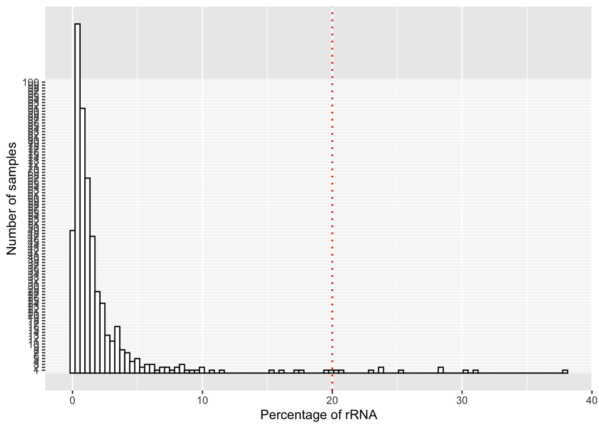

```r
ggplot(general_stats, aes(x=Picard_mqc.generalstats.picard.PCT_RIBOSOMAL_BASES)) +
  geom_histogram(bins = 100,
                 colour="black", fill="white", xlab="test") +
  labs(x="Percentage of rRNA", y="Number of samples") +
  geom_vline(xintercept = 20, linetype="dotted", color="red", size=0.7) +
  scale_y_continuous(breaks = (1:100))
```

# mRNA mapping

### mRNA mapping < 10%

```r
mrna_mapping_10 = general_stats$Sample[which(general_stats$Picard_mqc.generalstats.picard.PCT_MRNA_BASES < 10)]
as.data.frame(mrna_mapping_10)
```

| mrna_mapping_10 |
| --- |
| 17-099-GTS-LPS |
| 17-099-THA-IFNy |
| 17-148-GTS-unstim |
| 18-021-GTS-unstim |
| 18-021-THA-LPS |
| 16-110-GFM-IFNy |
| 16-110-GFM-TNFa |
| 16-110-THA-LPS |
| 16-112-GFM-TNFa |
| 16-112-GTS-IFNy |

[output cut: 80 more lines]

### mRNA mapping < 5%

```r
mrna_mapping_5 = general_stats$Sample[which(general_stats$Picard_mqc.generalstats.picard.PCT_MRNA_BASES < 5)]
as.data.frame(mrna_mapping_5)
```

| mrna_mapping_5 |
| --- |
| 17-148-GTS-unstim |
| 13-095-CC-unstim |
| 14-005-GTS-LPS |
| 14-046-GFM-unstim |
| 14-069-GTS-LPS |
| 14-074-GFM-LPS |
| 14-078-GFM-DEX |
| 14-078-GFM-LPS |
| 15-018-GFM-ATP |
| 15-021-THA-unstim |

[output cut: 1 more lines]

### PICARD < 5% coding mapping

```r
coding_mapping = picard_rnaseqmetrics[,"Coding"] / rowSums(picard_rnaseqmetrics[,-1])
names(coding_mapping) = picard_rnaseqmetrics$Sample
filter_coding = coding_mapping < 0.05

names(filter_coding)[which(filter_coding == TRUE)]
```

[1] “13-051-NA-IFNy” “13-051-NA-LPS” “13-056-GFM-IFNy”  
[4] “13-056-GFM-LPS” “13-074-CC-IFNy” “13-074-CC-LPS”  
[7] “13-077-CC-LPS” “13-095-CC-unstim” “13-095-GFM-unstim” [10] “14-005-CC-unstim” “14-005-GFM-IFNy” “14-005-GFM-R848”  
[13] “14-005-GFM-TNFa” “14-005-GFM-unstim” “14-005-GTS-LPS”  
[16] “14-005-GTS-unstim” “14-010-CC-LPS” “14-015-GFM-unstim” [19] “14-015-GTS-LPS” “14-015-GTS-unstim” “14-046-GFM-unstim” [22] “14-051-GFM-LPS” “14-053-CC-unstim” “14-055-CC-IFNy”  
[25] “14-055-CC-LPS” “14-055-CC-unstim” “14-063-GTS-unstim” [28] “14-069-GTS-IFNy” “14-069-GTS-LPS” “14-069-GTS-unstim” [31] “14-074-CC-LPS” “14-074-CC-unstim” “14-074-GFM-LPS”  
[34] “14-074-GFM-unstim” “14-075-GFM-unstim” “14-078-GFM-DEX”  
[37] “14-078-GFM-IL4” “14-078-GFM-LPS” “14-078-GFM-unstim” [40] “15-018-GFM-ATP” “15-018-GFM-DEX” “15-018-GFM-IL4”  
[43] “15-018-GFM-LPS” “15-018-GFM-unstim” “15-021-THA-unstim” [46] “15-024-GFM-unstim” “15-024-THA-unstim” “15-055-GFM-unstim” [49] “16-003-GFS-IFNy” “16-003-GFS-LPS” “16-003-SVZ-IFNy”  
[52] “16-003-SVZ-LPS” “16-003-SVZ-R848” “16-003-SVZ-TNFa”  
[55] “16-003-THA-LPS” “16-028-GTS-LPS” “16-028-GTS-unstim” [58] “16-049-GTS-LPS” “16-049-GTS-unstim” “16-110-GFM-IFNy”  
[61] “16-110-GFM-TNFa” “16-110-THA-LPS” “16-112-GFM-LPS”  
[64] “16-112-GFM-TNFa” “16-112-GTS-IFNy” “16-112-GTS-LPS”  
[67] “16-112-GTS-unstim” “16-112-THA-LPS” “16-112-THA-unstim” [70] “16-117-GFM-DEX” “16-117-GFM-LPS” “16-117-GFM-R848”  
[73] “16-117-GFM-TNFa” “16-118-GFM-IFNy” “16-118-GFM-LPS”  
[76] “16-118-GFM-TNFa” “16-118-GTS-LPS” “16-118-GTS-unstim” [79] “17-003-GTS-unstim” “17-003-THA-IFNy” “17-017-GTS-unstim” [82] “17-017-THA-LPS” “17-029-GFM-LPS” “17-029-GTS-unstim” [85] “17-043-GFM-IFNy” “17-043-GFM-LPS” “17-043-GFM-R848”  
[88] “17-043-GFM-TNFa” “17-043-GFM-unstim” “17-043-GTS-unstim” [91] “17-043-THA-LPS” “17-078-GFM-LPS” “17-078-GFM-R848”  
[94] “17-078-GFM-TNFa” “17-078-GFM-unstim” “17-094-GTS-LPS”  
[97] “17-097-GTS-LPS” “17-099-GTS-LPS” “17-099-THA-IFNy”  
[100] “17-124-GFM-unstim” “17-148-GTS-LPS” “17-148-GTS-unstim” [103] “18-0198-GFM-LPS” “18-021-GTS-unstim” “18-021-THA-LPS”  
[106] “18-064-GFM-ATP”

```r
data.table(filter_coding)
```

| filter_coding |
| --- |
| TRUE |
| TRUE |
| FALSE |
| FALSE |
| FALSE |
| FALSE |
| TRUE |
| TRUE |
| FALSE |
| FALSE |

[output cut: 523 more lines]

### Distribution plot PICARD: < 5% coding regions

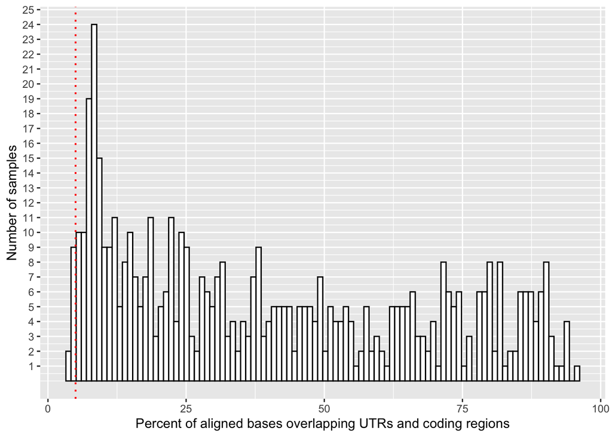

```r
ggplot(general_stats, aes(x=Picard_mqc.generalstats.picard.PCT_MRNA_BASES)) +
  geom_histogram(bins = 100,
                 colour="black", fill="white", xlab="test") +
  labs(x="Percent of aligned bases overlapping UTRs and coding regions", y="Number of samples") +
  geom_vline(xintercept = 5, linetype="dotted", color="red", size=0.7) +
  scale_y_continuous(breaks = (1:100))
```

### Distribution plot PICARD: 10% coding regions

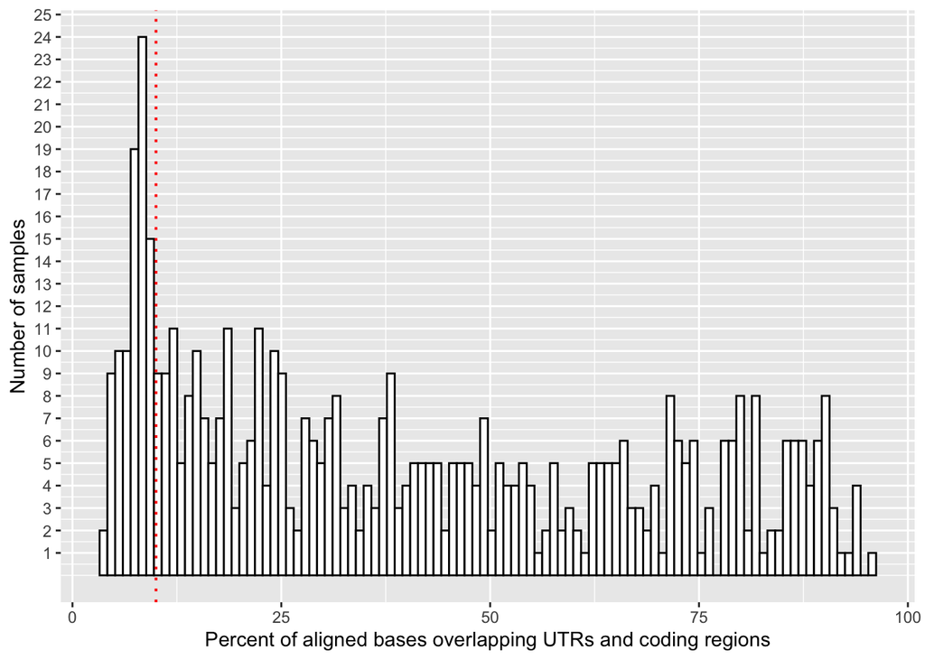

```r
ggplot(general_stats, aes(x=Picard_mqc.generalstats.picard.PCT_MRNA_BASES)) +
  geom_histogram(bins = 100,
                 colour="black", fill="white", xlab="test") +
  labs(x="Percent of aligned bases overlapping UTRs and coding regions", y="Number of samples") +
  geom_vline(xintercept = 10, linetype="dotted", color="red", size=0.7) +
  scale_y_continuous(breaks = (1:100))
```

# Gene coverage plot

```r
#check dataframe
multiqc_picard_coverage[1:10, 1:6]
```

|  | 0 | 1 | 2 | 3 | 4 | 5 |
| --- | --- | --- | --- | --- | --- | --- |
| 13-051-NA-IFNy | 0.300965 | 0.342670 | 0.395262 | 0.450857 | 0.500259 | 0.548744 |
| 13-051-NA-LPS | 0.288671 | 0.327072 | 0.373270 | 0.424037 | 0.473820 | 0.527181 |
| 13-051-NA-unstim | 0.294282 | 0.337845 | 0.399570 | 0.458347 | 0.512271 | 0.568627 |
| 13-054-CC-IFNy | 0.242727 | 0.278563 | 0.327355 | 0.371304 | 0.418472 | 0.469338 |
| 13-054-CC-LPS | 0.244685 | 0.278994 | 0.330070 | 0.378772 | 0.426247 | 0.477317 |
| 13-054-CC-unstim | 0.258629 | 0.293941 | 0.343500 | 0.394874 | 0.444210 | 0.496089 |
| 13-056-GFM-IFNy | 0.296730 | 0.336912 | 0.390717 | 0.439447 | 0.485305 | 0.533475 |
| 13-056-GFM-LPS | 0.295048 | 0.330878 | 0.378005 | 0.426640 | 0.471571 | 0.516512 |
| 13-056-GFM-TNFa | 0.304426 | 0.345266 | 0.401569 | 0.456734 | 0.511181 | 0.565316 |
| 13-056-GFM-unstim | 0.294218 | 0.334060 | 0.387388 | 0.437122 | 0.486448 | 0.537226 |

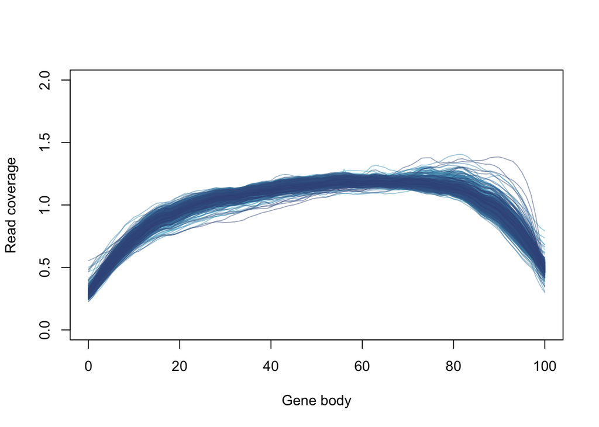

```r
#create plot
x = colnames(multiqc_picard_coverage)
x = as.numeric(x)
colfunc <- colorRampPalette(c("#4DBBD5FF", "#3C5488FF")) # Blue colors
colors = alpha(colfunc(nrow(multiqc_picard_coverage)), alpha = 0.5) # Ajuste o alpha pra ter mais ou menos transparencia
y = multiqc_picard_coverage[1,]
plot(x, y, type = "l", xlab = "Gene body", ylab = "Read coverage", col=colors[1], ylim = c(0,2))
for (i in 2:nrow(multiqc_picard_coverage))
{
  y = multiqc_picard_coverage[i,]
  lines(x,y, col=colors[i])
}
```

### Table with samples 95 position (degraded: ’3 end)

```r
cov_95 = multiqc_picard_coverage$'95'
cov_95 = as.data.frame(cov_95)
rownames(cov_95) = rownames(multiqc_picard_coverage)
colnames(cov_95) = c("position_95")
cov_95_ordered = cov_95[order(cov_95$position_95, decreasing = T),,drop=F]
data.table(cov_95_ordered)
```

| position_95 |
| --- |
| 1.260062 |
| 1.123975 |
| 1.060071 |
| 1.045566 |
| 1.040268 |
| 1.016981 |
| 0.988973 |
| 0.984077 |
| 0.957423 |
| 0.954709 |

[output cut: 523 more lines]

### List of samples 95 coverage

```r
cov_95 = multiqc_picard_coverage$'95'
cov_95 = as.data.frame(cov_95)
rownames(cov_95) = rownames(multiqc_picard_coverage)
colnames(cov_95) = c("position_95")
cov_95_ordered = cov_95[order(cov_95$position_95, decreasing = T),,drop=F]
data.table(cov_95_ordered)
```

| position_95 |
| --- |
| 1.260062 |
| 1.123975 |
| 1.060071 |
| 1.045566 |
| 1.040268 |
| 1.016981 |
| 0.988973 |
| 0.984077 |
| 0.957423 |
| 0.954709 |

[output cut: 523 more lines]

### Exclude samples 95 coverage in gene coverage plot

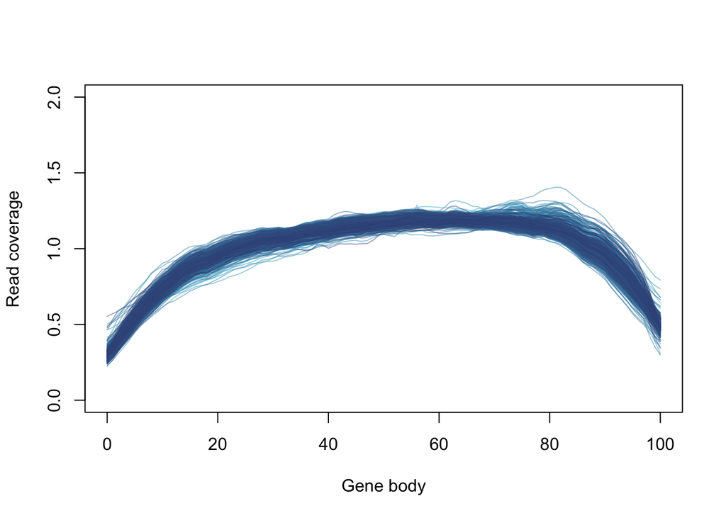

```r
exclude = rownames(cov_95_ordered)[1:6]
multiqc_picard_coverage_filt = multiqc_picard_coverage[! rownames(multiqc_picard_coverage) %in% exclude ,]
x = colnames(multiqc_picard_coverage_filt)
x = as.numeric(x)
colfunc <- colorRampPalette(c("#4DBBD5FF", "#3C5488FF")) # Blue colors
colors = alpha(colfunc(nrow(multiqc_picard_coverage_filt)), alpha = 0.5) # Ajuste o alpha pra ter mais ou menos transparencia
y = multiqc_picard_coverage_filt[1,]
plot(x, y, type = "l", xlab = "Gene body", ylab = "Read coverage", col=colors[1], ylim = c(0,2))
for (i in 2:nrow(multiqc_picard_coverage_filt))
{
  y = multiqc_picard_coverage_filt[i,]
  lines(x,y, col=colors[i])
}
```

# Filters option 1

```r
outlier_samples = c("MG-16-CER-RNA", "MG-08-CER-RNA", "13-095-GTS-unstim", "MG-15-SVZ-RNA", "MG-24-MGF-RNA", "14-046-GTS-unstim", "14-046-GFM-IL4", "16-117-THA-LPS", "16-074-GFM-unstim", "16-003-SVZ-TNFa")

Degraded_RNA = c("MG-24-HIP-RNA", "MG-12-CER-RNA", "15-089-GTS-unstim", "MG-15-SVZ-RNA", "MG-08-CER-RNA")

list_filters = list(filter1 = star_alignment_1m, filter2 = mrna_mapping_5, filter3 = ribosomal_bases_20, filter4 = outlier_samples, filter5 = Degraded_RNA)
list_filters
```

$filter1 [1] “18-064-GFM-IFNy” “18-064-GFM-unstim” “18-105-GTS-LPS”  
[4] “MG-15-SN-RNA” “16-117-SVZ-unstim” “17-003-GTS-LPS”  
[7] “15-055-GFM-DEX” “15-089-GTS-unstim” “15-089-THA-LPS”  
[10] “15-089-THA-unstim”

$filter2 [1] “17-148-GTS-unstim” “13-095-CC-unstim” “14-005-GTS-LPS”  
[4] “14-046-GFM-unstim” “14-069-GTS-LPS” “14-074-GFM-LPS”  
[7] “14-078-GFM-DEX” “14-078-GFM-LPS” “15-018-GFM-ATP”  
[10] “15-021-THA-unstim” “14-063-GTS-unstim”

$filter3 [1] “18-079-GFM-LPS” “MG-08-CER-RNA” “MG-13-CER-RNA”  
[4] “MG-16-CER-RNA” “MG-24-HIP-RNA” “MG-24-MGF-RNA”  
[7] “14-046-GFM-IL4” “14-046-GFM-LPS” “14-046-GFM-TNFa”  
[10] “14-046-GTS-unstim” “14-046-GFM-DEX”

$filter4 [1] “MG-16-CER-RNA” “MG-08-CER-RNA” “13-095-GTS-unstim” [4] “MG-15-SVZ-RNA” “MG-24-MGF-RNA” “14-046-GTS-unstim” [7] “14-046-GFM-IL4” “16-117-THA-LPS” “16-074-GFM-unstim” [10] “16-003-SVZ-TNFa”

$filter5 [1] “MG-24-HIP-RNA” “MG-12-CER-RNA” “15-089-GTS-unstim” [4] “MG-15-SVZ-RNA” “MG-08-CER-RNA”

```r
samples2remove = unlist(list_filters)
```

### Unique samples 2 remove

```r
unique(samples2remove)
```

[1] “18-064-GFM-IFNy” “18-064-GFM-unstim” “18-105-GTS-LPS”  
[4] “MG-15-SN-RNA” “16-117-SVZ-unstim” “17-003-GTS-LPS”  
[7] “15-055-GFM-DEX” “15-089-GTS-unstim” “15-089-THA-LPS”  
[10] “15-089-THA-unstim” “17-148-GTS-unstim” “13-095-CC-unstim” [13] “14-005-GTS-LPS” “14-046-GFM-unstim” “14-069-GTS-LPS”  
[16] “14-074-GFM-LPS” “14-078-GFM-DEX” “14-078-GFM-LPS”  
[19] “15-018-GFM-ATP” “15-021-THA-unstim” “14-063-GTS-unstim” [22] “18-079-GFM-LPS” “MG-08-CER-RNA” “MG-13-CER-RNA”  
[25] “MG-16-CER-RNA” “MG-24-HIP-RNA” “MG-24-MGF-RNA”  
[28] “14-046-GFM-IL4” “14-046-GFM-LPS” “14-046-GFM-TNFa”  
[31] “14-046-GTS-unstim” “14-046-GFM-DEX” “13-095-GTS-unstim” [34] “MG-15-SVZ-RNA” “16-117-THA-LPS” “16-074-GFM-unstim” [37] “16-003-SVZ-TNFa” “MG-12-CER-RNA”

### Upset plot

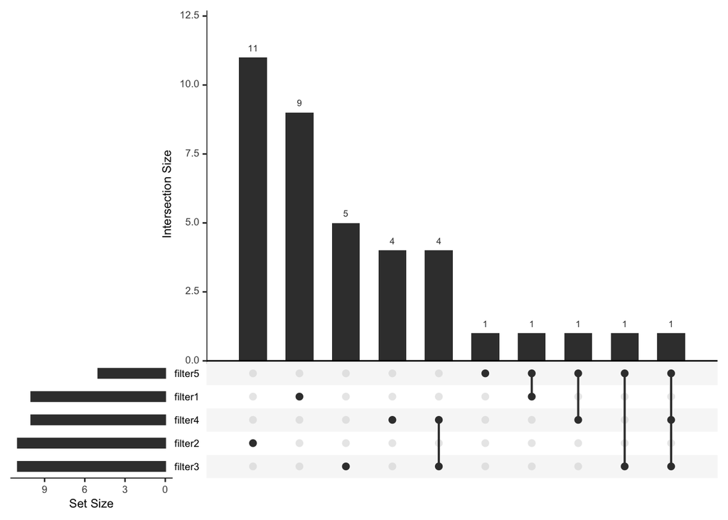

```r
upset(fromList(list_filters), order.by = "freq")
```

# Filters option 2

#Filter 1 < 5 M mapped reads: 21 samples #Filter 2 mRNA mapping < 5%: 11 samples #Filter 3 Ribosomal bases > 20%: 11 samples #Filter 4 Degraded RNA: 5 samples

```r
Degraded_RNA = c("MG-24-HIP-RNA", "MG-12-CER-RNA", "15-089-GTS-unstim", "MG-15-SVZ-RNA", "MG-08-CER-RNA")

list_filters = list(filter1 = star_alignment_5m, filter2 = mrna_mapping_5, filter3 = ribosomal_bases_20, filter4 = Degraded_RNA)
list_filters
```

$filter1 [1] “18-021-GFM-DEX” “18-021-GFM-LPS” “18-064-GFM-ATP”  
[4] “18-064-GFM-IFNy” “18-064-GFM-unstim” “18-105-GTS-LPS”  
[7] “18-105-GTS-unstim” “18-118-GFM-IL4” “MG-15-SN-RNA”  
[10] “16-117-SVZ-unstim” “17-003-GTS-LPS” “17-017-GFM-unstim” [13] “17-032-SVZ-IFNy” “13-087-CC-LPS” “14-075-GFM-IFNy”  
[16] “14-075-GFM-LPS” “14-075-GFM-TNFa” “15-055-GFM-DEX”  
[19] “15-089-GTS-unstim” “15-089-THA-LPS” “15-089-THA-unstim”

$filter2 [1] “17-148-GTS-unstim” “13-095-CC-unstim” “14-005-GTS-LPS”  
[4] “14-046-GFM-unstim” “14-069-GTS-LPS” “14-074-GFM-LPS”  
[7] “14-078-GFM-DEX” “14-078-GFM-LPS” “15-018-GFM-ATP”  
[10] “15-021-THA-unstim” “14-063-GTS-unstim”

$filter3 [1] “18-079-GFM-LPS” “MG-08-CER-RNA” “MG-13-CER-RNA”  
[4] “MG-16-CER-RNA” “MG-24-HIP-RNA” “MG-24-MGF-RNA”  
[7] “14-046-GFM-IL4” “14-046-GFM-LPS” “14-046-GFM-TNFa”  
[10] “14-046-GTS-unstim” “14-046-GFM-DEX”

$filter4 [1] “MG-24-HIP-RNA” “MG-12-CER-RNA” “15-089-GTS-unstim” [4] “MG-15-SVZ-RNA” “MG-08-CER-RNA”

```r
samples2remove = unlist(list_filters)
```

### Unique samples 2 remove

```r
unique(samples2remove)
```

[1] “18-021-GFM-DEX” “18-021-GFM-LPS” “18-064-GFM-ATP”  
[4] “18-064-GFM-IFNy” “18-064-GFM-unstim” “18-105-GTS-LPS”  
[7] “18-105-GTS-unstim” “18-118-GFM-IL4” “MG-15-SN-RNA”  
[10] “16-117-SVZ-unstim” “17-003-GTS-LPS” “17-017-GFM-unstim” [13] “17-032-SVZ-IFNy” “13-087-CC-LPS” “14-075-GFM-IFNy”  
[16] “14-075-GFM-LPS” “14-075-GFM-TNFa” “15-055-GFM-DEX”  
[19] “15-089-GTS-unstim” “15-089-THA-LPS” “15-089-THA-unstim” [22] “17-148-GTS-unstim” “13-095-CC-unstim” “14-005-GTS-LPS”  
[25] “14-046-GFM-unstim” “14-069-GTS-LPS” “14-074-GFM-LPS”  
[28] “14-078-GFM-DEX” “14-078-GFM-LPS” “15-018-GFM-ATP”  
[31] “15-021-THA-unstim” “14-063-GTS-unstim” “18-079-GFM-LPS”  
[34] “MG-08-CER-RNA” “MG-13-CER-RNA” “MG-16-CER-RNA”  
[37] “MG-24-HIP-RNA” “MG-24-MGF-RNA” “14-046-GFM-IL4”  
[40] “14-046-GFM-LPS” “14-046-GFM-TNFa” “14-046-GTS-unstim” [43] “14-046-GFM-DEX” “MG-12-CER-RNA” “MG-15-SVZ-RNA”

### Upset plot

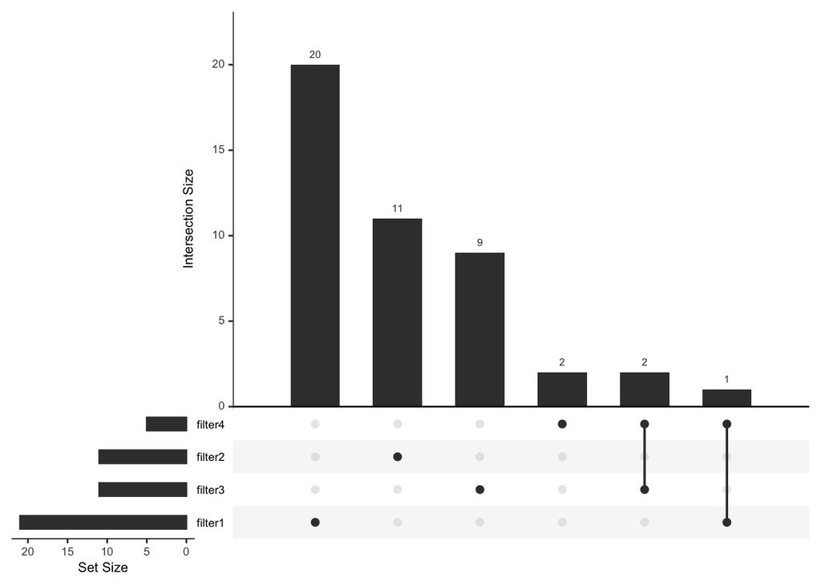

```r
upset(fromList(list_filters), order.by = "freq")
```

# Filters option 3 (used)

#filter 1: < 1 M reads: 10 samples #filter 2: mRNA mapping < 5%: 11 samples #filter 3: ribosomal bases > 20%: 11 samples #filter 4: RNA degraded: 5 samples #filter 5: duplicates: 2 samples #filter 6: outlier (PCA): 1 sample

```r
setwd("~/Documents/MiGASti/Databases")
Degraded_RNA = c("MG-24-HIP-RNA", "MG-12-CER-RNA", "15-089-GTS-unstim", "MG-15-SVZ-RNA", "MG-08-CER-RNA")
duplicates =c("15-024-GFM_unstim", "16-074-GFM-unstim")
outliers =c("13-095-GTS-unstim")

list_filters = list(filter1 = star_alignment_1m, filter2 = mrna_mapping_5, filter3 = ribosomal_bases_20, filter4 = Degraded_RNA, filter5 = duplicates, filter6 = outliers)
list_filters
```

$filter1 [1] “18-064-GFM-IFNy” “18-064-GFM-unstim” “18-105-GTS-LPS”  
[4] “MG-15-SN-RNA” “16-117-SVZ-unstim” “17-003-GTS-LPS”  
[7] “15-055-GFM-DEX” “15-089-GTS-unstim” “15-089-THA-LPS”  
[10] “15-089-THA-unstim”

$filter2 [1] “17-148-GTS-unstim” “13-095-CC-unstim” “14-005-GTS-LPS”  
[4] “14-046-GFM-unstim” “14-069-GTS-LPS” “14-074-GFM-LPS”  
[7] “14-078-GFM-DEX” “14-078-GFM-LPS” “15-018-GFM-ATP”  
[10] “15-021-THA-unstim” “14-063-GTS-unstim”

$filter3 [1] “18-079-GFM-LPS” “MG-08-CER-RNA” “MG-13-CER-RNA”  
[4] “MG-16-CER-RNA” “MG-24-HIP-RNA” “MG-24-MGF-RNA”  
[7] “14-046-GFM-IL4” “14-046-GFM-LPS” “14-046-GFM-TNFa”  
[10] “14-046-GTS-unstim” “14-046-GFM-DEX”

$filter4 [1] “MG-24-HIP-RNA” “MG-12-CER-RNA” “15-089-GTS-unstim” [4] “MG-15-SVZ-RNA” “MG-08-CER-RNA”

$filter5 [1] “15-024-GFM_unstim” “16-074-GFM-unstim”

$filter6 [1] “13-095-GTS-unstim”

```r
samples2remove = unlist(list_filters)
write.table(samples2remove, "samples2remove.txt")
```

### Unique samples 2 remove

```r
unique(samples2remove)
```

[1] “18-064-GFM-IFNy” “18-064-GFM-unstim” “18-105-GTS-LPS”  
[4] “MG-15-SN-RNA” “16-117-SVZ-unstim” “17-003-GTS-LPS”  
[7] “15-055-GFM-DEX” “15-089-GTS-unstim” “15-089-THA-LPS”  
[10] “15-089-THA-unstim” “17-148-GTS-unstim” “13-095-CC-unstim” [13] “14-005-GTS-LPS” “14-046-GFM-unstim” “14-069-GTS-LPS”  
[16] “14-074-GFM-LPS” “14-078-GFM-DEX” “14-078-GFM-LPS”  
[19] “15-018-GFM-ATP” “15-021-THA-unstim” “14-063-GTS-unstim” [22] “18-079-GFM-LPS” “MG-08-CER-RNA” “MG-13-CER-RNA”  
[25] “MG-16-CER-RNA” “MG-24-HIP-RNA” “MG-24-MGF-RNA”  
[28] “14-046-GFM-IL4” “14-046-GFM-LPS” “14-046-GFM-TNFa”  
[31] “14-046-GTS-unstim” “14-046-GFM-DEX” “MG-12-CER-RNA”  
[34] “MG-15-SVZ-RNA” “15-024-GFM_unstim” “16-074-GFM-unstim” [37] “13-095-GTS-unstim”

### Upset plot

[figure not shown]

```r
upset(fromList(list_filters), order.by = "freq")
```